# Q2 EDA with ggplot2

Leong Shu Hui Felicia

## Finding 1

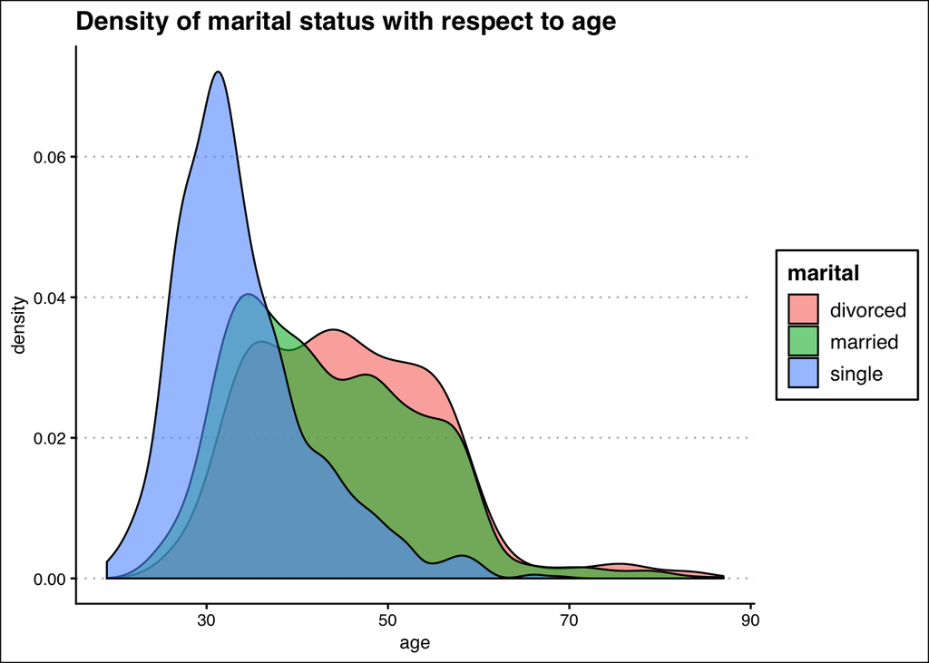

It can be seen that a large proportion of singles are below the age of 40.  
People start getting married and divorced after the age of 30.

## Finding 2

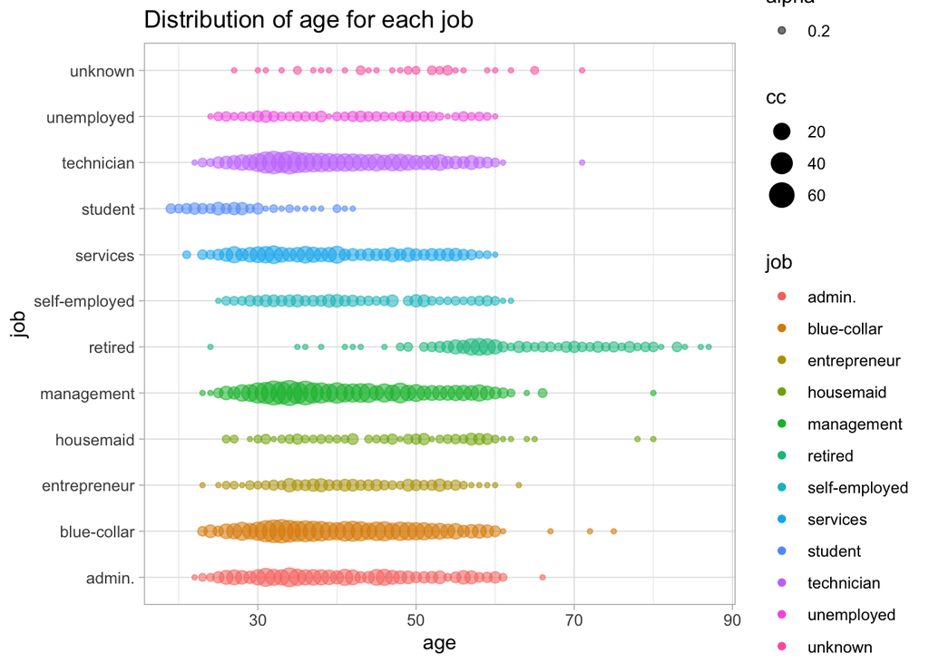

Most jobs are filled between the age of 20 and 60.  
Unemployed stayed relatively constant.  
People are students from before the age of 20 up till 40.  
People started retiring after 50 years of age.

## Finding 3

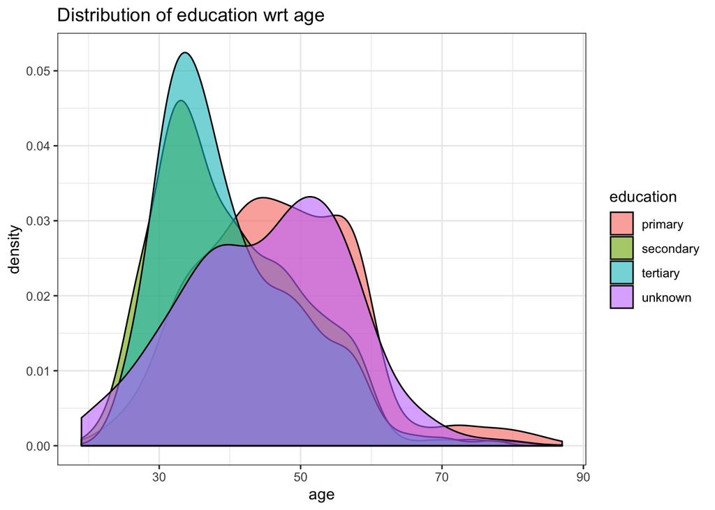

Younger people are more likely to have higher education (tertiary or secondary).  
Those who are older are more likely to only have primary education.

## Finding 4

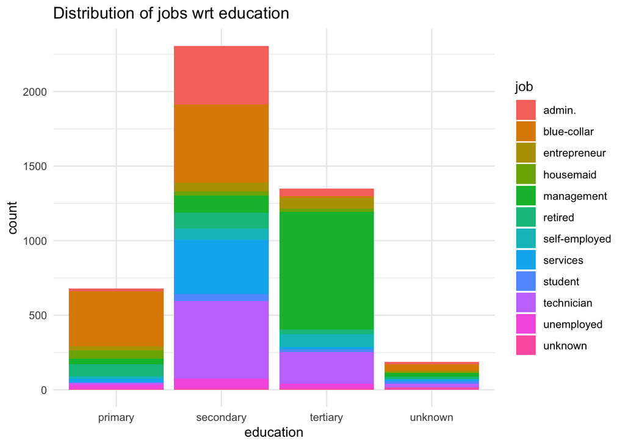

People with primary education are more likely to be blue collar workers.  
People with secondary education are more likely to be blue collar workers,admin,services or technicians.  
People with tertiary education are likely to work in management.

## Finding 5

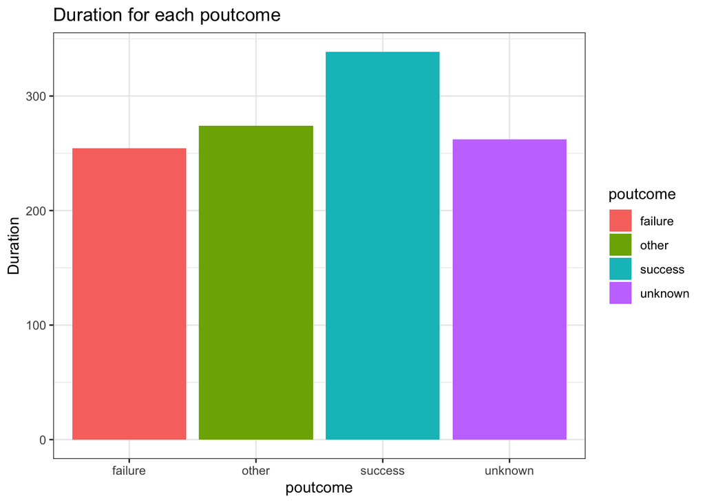

Those with a poutcome of success have a higher duration than the others.

## Finding 6

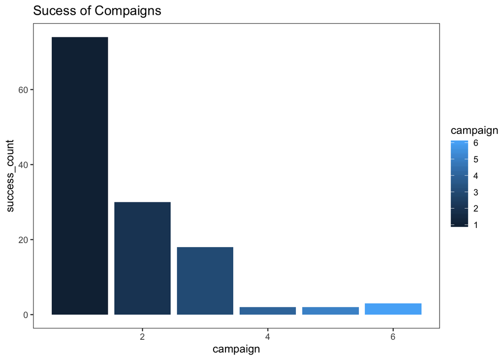

Campaign 1 was the most successful one.  
Success of campaigns is declining, with a decreasing trend in the number of successes.

## Finding 7

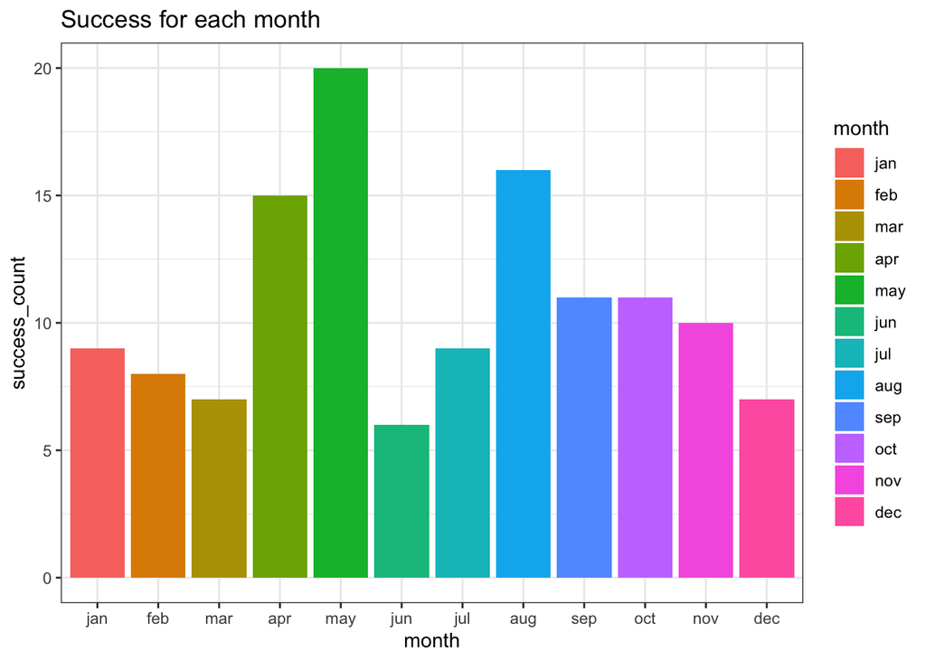

The highest number of success is in the month of May.  
However, it seems that there is no pattern or seasonal relationship for the successes of each month.

## Finding 8

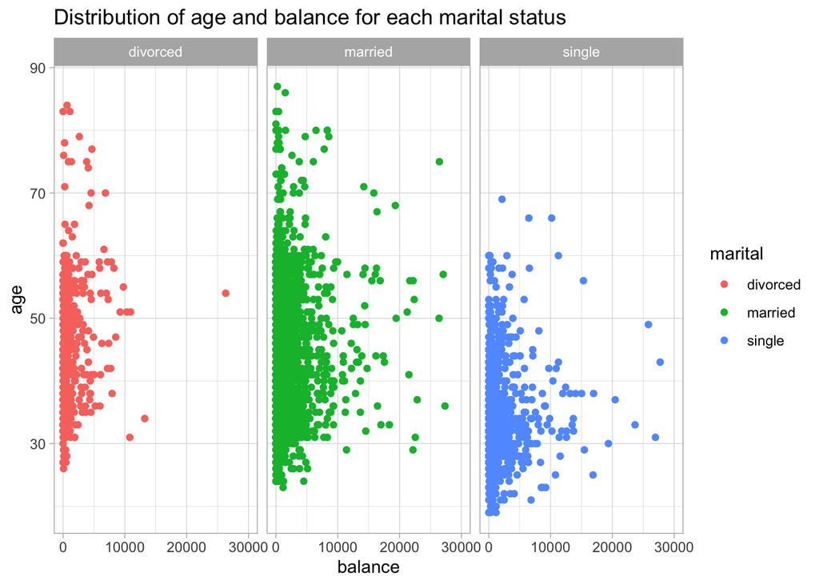

It can be seen that those who are married or single seems to have more balance in their accounts than those who are divorced at all ages.  
This may mean that people who have trouble keeping their marriage may have trouble keeping their finances in order too.

## Finding 9

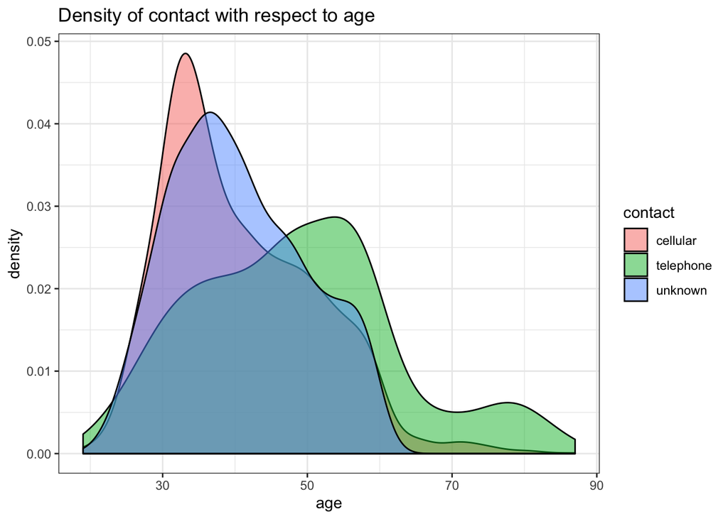

Younger people are more likely to be contacted by cellular while older ones are more likely to be contacted by telephone.

## Finding 10

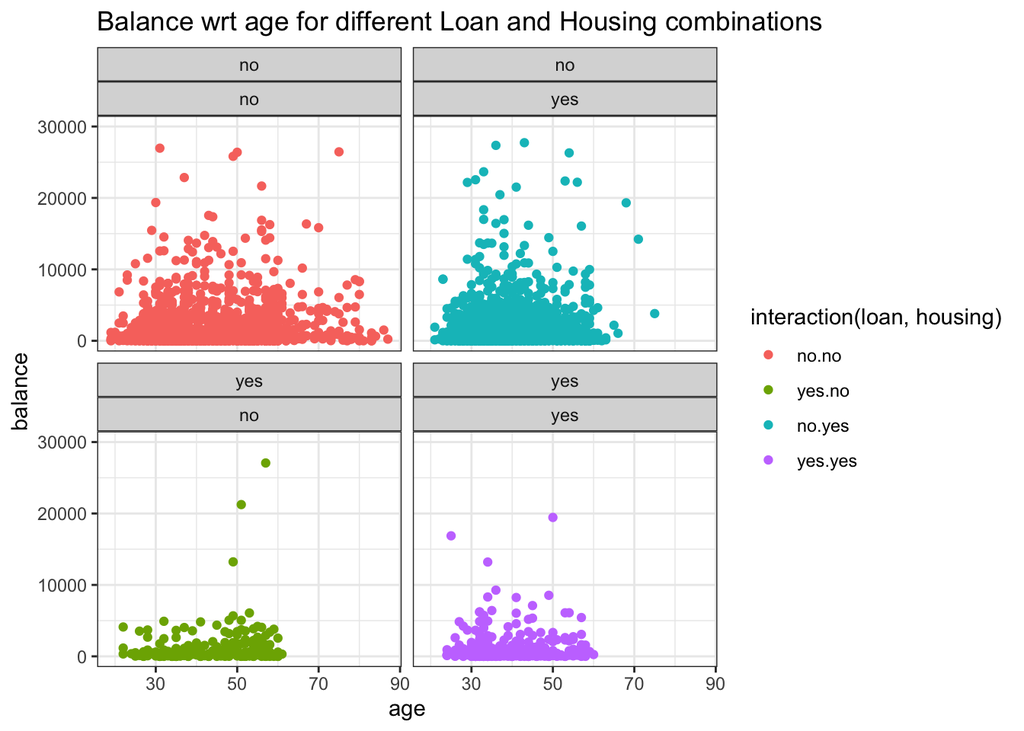

People without loans have higher balances on average at all ages and all housing.  
Those with housing have a smaller age range than those without housing.  
There are more people without loans than with loans.

### Hope you enjoyed my 10 findings!